# Syllabus

**Warning**

**Draft.** Aspects of this syllabus may change. Last update: August 26, 2026.

PSCI-2300: Data and Politics I: Computation and Visualization

Prof. Josh Clinton

Vanderbilt University · Fall 2026

**Mondays & Wednesdays · 2:30–3:45 p.m. · Commons 335**

*AXLE: Social and Behavioral Sciences · CORE: LB–Inquiry Lab · Eligible for Public Policy Studies*

How can we use polls to predict election outcomes? What is the impact of minimum wage laws on employment? How can we detect evidence of discrimination? When does a correlation indicate causation? This course will teach you how to address these and other social science questions through data analysis. The course will introduce basic principles of statistical inference and programming skills for data analysis with the goal of providing you with the foundation necessary to analyze data in your own research and to also become more informed and critical consumers of statistical claims made in the news media, in policy reports, and in academic research.

I do not assume you know anything, but I do assume that you are curious, capable, and self-driven as you are a Commodore.

I love this stuff. In part because I think what we are going to learn about is terribly important, perhaps moreso now than every before. Fundamentally this class about making and evaluating arguments. It is a class about how, not what, to think about the world and it is a class that I hope will both empower you and also transform how you see and understand the world.

A central thesis of this class is that to use data is to make an argument about the world – but an argument that follows some strict rules about the form that the argument takes and also uses language that contains meaning (e.g., correlation, regression). Data is often used to support different sides of an argument about the world, this class aspired to help you better intepret, evaluate, and make data-based claims.

Fundamentally, this class is not about math, statistics, or programming. Fundamentally, this class is about developing critical thinking skills and empowering you with a set of skills to navigate our data-rich reality. I see data science as an endeavor that is based fundamentally on thinking and creativity – identifying puzzles, questioning claims, figuring out how to answer questions with non-obvious answers. It is also an ongoing quest that demands intellectual humility. While it would be hard to characterize Feynman as humble, his point about the epistemic humility that is required to be truly scientific is worth noting as it is a perspective that I hope this course take seriously.

> The scientist has a lot of experience with ignorance and doubt and uncertainty, and this experience is of very great importance, I think. When a scientist doesn’t know the answer to a problem, he is ignorant. When he has a hunch as to what the result is, he is uncertain. And when he is pretty darn sure of what the result is going to be, he is in some doubt. Scientific knowledge is a body of statements of varying degrees of certainty – some most unsure, some nearly sure, none absolutely certain.

> — Richard P. Feynman, “The Value of Science” (1955)[^1]

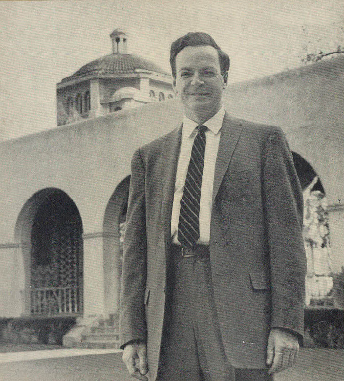

*Richard Feynman, circa 1960.*[^2]

## Who Should and Should Not Take This Course

PSCI 2300 is an introductory statistics and data analysis course, and I encourage students who take this course to continue using statistics. In today’s information-overloaded world, data are available everywhere and the role of statistics is rapidly increasing in academia, business, medicine, public policy, and many other parts of society. I strongly believe that it is an essential skill that everyone benefits from. To quote a headline from The New York Times: “For Today’s Graduate, Just One Word: Statistics.”

Here is a checklist to consider when deciding whether to take this class:

- I am a political science major or someone who is interested in quantitative social science.
- In addition to developing my knowledge of statistical concepts, I want to learn the computational skills needed to manipulate and analyze data using the open-source statistical language R.
- I am willing to spend time outside of classroom each week to keep up with the course materials.
- I would like to use statistics in a paper and/or job in the future.
- I understand that this is an introductory class so we will focus primarily, but not exclusively, on developing a conceptual understanding. We will not dive too deep into the mathematical foundations or advanced computational models and methods.

## Contact Information

Prof. Josh Clinton: josh.clinton@vanderbilt.edu  
Office Hours: Commons 342: Fridays, 9:00–11:00 a.m. (or by email)  
Sign-Up for a 30-minute slot: https://calendly.com/josh-clinton/office-hours-jdc

Teaching Assistant:  
Alexander Dean: alexander.r.dean@vanderbilt.edu  
Office Hours: Mondays 9:00–11:00 a.m.  
Sign-Up for a 15-minute slot (or 2 if needed): [TBA]

When signing up for office hours please let us know what issue you are having. It also helps if you send us the code in advance so we can take a look at it before you arrive. It is very hard to debug code in real time so the more advance information we have on the issue you are having the better!

## Logistics

Sessions:  
MW from 2:30 PM to 3:45 PM in Commons 335

Sessions will be interactive and vary over the course of the semester. The modal class will consist of me introducing concepts and code motivated by real-world questions and data and running the analyses in real-time with you running the same analyses in class. Every class will also have portions that will prompt you to write new code snippets building off of what we are covering to make sure you are tracking with what we are doing. I strongly believe in the importance of being question-driven, not data driven, in your analyses (for reasons that will become clear.). As a result, we will explore data science concepts motivated around trying to answer “real world” questions using actual, real data.

All session notes/code – and any data we will be using – will be posted in the appropriate folder prior to each class on the course website. Make sure you download all of this prior to class and place in the relevant folder. (If I must make last minute changes that require you to download new files in class, I will let you know.)

We meet 28 times. I am away the week of the midterm election because I have to project the 2026 midterm elections for NBC News and away Dec 2 because Vanderbilt has me giving a talk in Palm Beach on prediction markets. The TA will administer Midterm 2 in class on Nov 2 and oversee the working meeting on Dec 2; there is **no class Nov 4** (you’re welcome!).

**Textbook:** None. We will use notes I circulate based on content that either I or my various collaborators have created. There are some free O’Reilly books available via the Vanderbilt Library that may also be useful and which cover similar material. In general, they are more code-driven than question driven. Perhaps the closest to this class – which isn’t very close! – is R for Data Science by Wickham, Çetinkaya-Rundel, and Grolemund: https://r4ds.hadley.nz/

**Software:** Yes please! Everything we use is freely available. I will circulate information on how to get everything installed if needed.  
We will program using the open-source statistical software R: http://www.r-project.org.  
We will interact with R using the IDE (Interactive Design Environment) called RStudio: https://posit.co/downloads/  
We will create documents and code using Rmarkdown: https://rmarkdown.rstudio.com/

## What you will learn

This course carries Vanderbilt’s **CORE Inquiry Lab (LB)** designation. Inquiry Lab courses teach students how rigorous research is designed, conducted, analyzed, and communicated. Through the class survey project and the other analyses in this course, you will:

1. formulate research questions and design and execute studies to investigate them;
2. analyze quantitative data using appropriate methods, interpret the results in context, and diagnose problems in data collection and analysis;
3. visualize results and communicate research findings effectively in writing and oral presentations; and
4. practice ethical research and work effectively with others.

The course also satisfies the **AXLE Social and Behavioral Sciences** requirement for students governed by AXLE and may satisfy part of the **Methods of Public Policy** requirement for the Public Policy Studies major.

By the end of this course you will be able to:

1. **Load, clean, and combine real data in R** — and recognize the operations where data manipulation silently goes wrong.
2. **Describe and visualize data** to answer a specific question, honestly.
3. **Quantify uncertainty** using resampling: confidence intervals, margins of error, and what they do and do not mean.
4. **Reason about causal claims** — what experiments can show, what observational data can and cannot support, and how to tell the difference.
5. **Build and evaluate simple predictive models** — regression, classification, and clustering — and know when they are being oversold.
6. **Verify analyses you did not write yourself** — including output produced by AI tools. Modern tools will happily produce code and conclusions for you; this course teaches you to be the person in the room who can tell whether they are right.

## AI Policy

**No AI through Session 6.** Do not use AI before Session 7. Never ever use AI for answering in-class questions. We will decide and discuss how to use AI on problem sets in Session 7 and we will actively use AI when analyzing the survey we field.

The rules for quizzes and exams are fixed: they are completed on paper, in class, closed-book, and without devices or AI.

## Course Assessment

It is my hope and expectation that anyone can be successful in this course if they put the work in and they are proactive with their learning. I know all of you want good grades, but you have to earn them – I cannot give you an A simply because you want to go to Law School. There is almost nothing I dislike more than dealing with grade complaints. If there is a mistake in grading – which is exceptionally rare – that is one thing, but if you are worried about your performance use the resources and assessments in the class to compensate for that. The TA and I are resources so use us - I do not enjoy giving bad grades, but I cannot give gifts. There is no hard curve in the class so how well you do is not a function of how well others do.

If you have/need additional accommodations please make sure that you take care of that through the Student Access office so that they can communicate directly with me.

| Component | Weight |
| --- | --- |
| Problem sets (6, completion-graded, lowest dropped) | 10% |
| Quizzes (6, in class, lowest two dropped) | 15% |
| Midterm exams (2 × 15%) | 30% |
| Group project | 15% |
| Final exam (cumulative) | 30% |

**Class Extra credit.** Four ways to earn a little back: (1) **Participation** – up to 1% based on engagement in class – be active and take ownership of your education!; (2) **Exams** (possible) bonus items; (3) **AI Fail** — documented catches of an AI tool producing wrong output or interpretation: submit the prompt, the output, and your R analysis demonstrating the error; (4) **DataViz Fail** – an example of a bad visualization of a relationship, or a bad intereprtation of a visualization: submit the image/offensive interprtation and a memo explaining the error.

**Problem sets (10%).** There are six, graded on good-faith completion — full credit for a serious attempt. If you get stuck, explain *why* you think it is wrong. Problem sets are deliberately low-stakes because they are *practice* - each one is followed by an in-class quiz based directly on the problem set so if you understand the problem set you will ace the quiz. I drop the lowest problem set – so each problem set is effectively 2% of your final grade.

**Quizzes (15%).** Six short (~15 minute) paper-and-pencil quizzes at the start of class. Each quiz occurs on the day its problem set is due and is based directly on that problem set. Dates are in the schedule. Your lowest **two** quiz scores are dropped – no makeup quizzes.

**Exams (60% total).** Two in-class midterms (**Wed Sep 30** and **Mon Nov 2**) and a cumulative final on **Monday, December 14 at 3:00 p.m.** (registrar-assigned slot). The TA will administer Midterm 2 while I am away for NBC election work. All exams are paper-and-pencil, closed-book, no devices. I will share practice problems so you have a sense of what to expect. Exams may include bonus items worth extra credit depending on the vibes of the class.

**Group project (15%): design, analyze, and interpret an original survey.** We will design, field, and analyze a survey in class. We will divide into teams, brainstorm, write questions, figure out an analysis plan, present and defend it, get data, analyze the data (perhaps using AI), interpret the results (using your brain), create a presentation (perhaps using AI), and then give it to class. There will be some sub-assignments along the way: a memo presenting and justifying the question wording and analysis plan, a presentation rubric, and a post-action report.

Four graded components:

1. *Proposed Question* What to ask and why?
2. *Written deliverable* (memo + code): completion-graded; AI permitted with disclosure.
3. *Presentation:* team grade against a rubric. Q&A follows each talk but is not scored.
4. *Post Action Report:* short, in-class paper and pencil questions about your team’s project.

## Notes on Problem Sets

For problem sets you are required to submit an electronic copy of the Rmarkdown file and compiled output to Brightspace using xxx.Rmd and xxx.pdf respectively as file names where xxx is your VUID. *Both must be submitted for credit!*

If you worked with others on the problem set, note that on your submitted problem set. If you use AI (once permitted) note that as well (model-type).

In my opinion, problem sets present an opportunity for you to collaborate and work together. At the same time, there is a clear distinction between permissible collaboration and unacceptable plagiarism. Programming necessitates that you reach your own understanding of the problem and discover a path to its solution – talking things through can help you identify a reasonable solution and help you correct errors in your code. During this time, collaborations are permitted and encouraged. When it comes time to write the final code and analyses, however, such discussions are no longer appropriate: the code and writing must be your own. The same goes with AI. Once we discuss it in class you can use it to help figure out possible coding errors in the ways that we discuss, but never simply ask it to give you the answer – you are all better than that.

Do not, under any circumstances, simply copy and paste another person’s code. Incorporating someone else’s code into your program in any form is a violation of academic regulations. Abetting plagiarism or unauthorized collaboration by sharing your code is also prohibited. Sharing code in digital form is an especially egregious violation: do not e-mail your code to anyone. Novices often have the misconception that copying and mechanically transforming a program (by rearranging independent code, renaming variables, or similar operations) makes it something different.

If you have any questions about these matters, please ask or consult the VU Honor System guidelines: https://www.vanderbilt.edu/student_handbook/the-honor-system/#statement-of-the-honor-code >

## Course norms

Politics is the subject of this course, and Fall 2026 is an election season. You are welcome to your political commitments — and this classroom evaluates *analysis*, not *conclusions*. The standard for every claim does not depend on the conclusion, but the method and process: what are the data, what was done, and does the evidence support it?

## Schedule

The full session-by-session schedule, with materials and data for each class, is below.

| Date | Session | Assignments & Assessments |
| --- | --- | --- |
| Aug 26 W | Introduction: Why This? Why Me? |  |
| Aug 31 M | Hello World! Central tendencies and what is ``typical” turnout? | *Install R, Test Markdown* |
| Sep 2 W | Data Wrangling: Surveying the Gap | PS1 posted |
| Sep 7 M | WORKSHOP: Wrangling with Authenticity |  |
| Sep 9 W | Univariate Description: Electoral Competitiveness & Himmicanes? | **Quiz 1** · PS1 due |
| Sep 14 M | Resampling Uncertainty: Red beats Blue? | PS2 posted |
| Sep 16 W | Leveraging AI: What it is, How it helps, How it hurts, How to use |  |
| Sep 21 M | Principles of DataViz: Do you launch? | **Quiz 2** · PS2 due |
| Sep 23 W | Univariate Visualizing: Insurance Fraud and Polling Error |  |
| Sep 28 M | Conditional Visualizing: Plotting Polls | PS3 posted |
| Sep 30 W | **MIDTERM 1** |  |
| Oct 5 M | Randomized Experiments & Causal Effects: Turning Out Social Pressure | **Quiz 3** · PS3 due |
| Oct 7 W | WORKSHOP: Auditing discrimination |  |
| Oct 12 M | Observational Causality?: Home Fields, Minimum Wages, Expanding Medicaid | PS4 posted |
| Oct 14 W | Correlation & Regression: Floridian Butterfly Ballots |  |
| Oct 19 M | Regression & prediction: Launches, Ballots, and Olympic Sprinters | **Quiz 4** · PS4 due · PS5 posted |
| Oct 21 W | Predicting Elections: Aggregating Polls? |  |
| Oct 26 M | Prediction Markets: Aggregating Wisdom? | **Quiz 5** · PS5 due |
| Oct 28 W | WORKSHOP: Writing a survey instrument | *instrument and analysis plans due* |
| Nov 2 M | **MIDTERM 2** |  |
| Nov 4 W | NO CLASS |  |
| Nov 9 M | Multiple Regression: Catching the Google Flu |  |
| Nov 11 W | Multiple Regression: More than a crosstab | PS6 posted |
| Nov 16 M | Logits and LASSOs: Who you with? |  |
| Nov 18 W | Text As Data: Who wrote the *Federalist Papers*? | **Quiz 6** · PS6 due |
| Nov 23 M | NO CLASS — Thanksgiving break |  |
| Nov 25 W | NO CLASS — Thanksgiving break |  |
| Nov 30 M | WORKSHOP: Survey Data and weighting |  |
| Dec 2 W | WORKSHOP: Analysis, Interpretation, Visualization |  |
| Dec 7 M | Team presentations |  |
| Dec 9 W | Wrap-Up Review |  |
| Dec 14 M, 3 p.m. | **FINAL EXAM** |  |

### Problem Sets and Quizzes

Each quiz occurs at the start of class on the day its problem set is due and is based directly on that problem set.

| Problem set | Posted | Due | Quiz |
| --- | --- | --- | --- |
| PS1 | Sep 2 | Sep 9 | Quiz 1 · Sep 9 |
| PS2 | Sep 14 | Sep 21 | Quiz 2 · Sep 21 |
| PS3 | Sep 28 | Oct 5 | Quiz 3 · Oct 5 |
| PS4 | Oct 12 | Oct 19 | Quiz 4 · Oct 19 |
| PS5 | Oct 19 | Oct 26 | Quiz 5 · Oct 26 |
| PS6 | Nov 11 | Nov 18 | Quiz 6 · Nov 18 |

### Session-by-Session Schedule

The descriptions below give the question and central task for each session. Specific examples, readings, and activities may change as the semester progresses, but the sequence of topics and assessments will remain the same unless I announce a change in class.

**1. Wednesday, August 26 — Introduction: Why This? Why Me?**  
Introduction to me and the course. Goals, hopes, and dreams. Installing software for the class.

**2. Monday, August 31 — Hello World! Central tendencies and what is ``typical” turnout?**  
Our first analysis – how do we measure what is “typical” and how does that seemingly simple decision change our conclusion? How do we measure turnout in the United States?

**3. Wednesday, September 2 — Data Wrangling: Surveying the Gap.**

How/why do we wrangle data using replicable code rather than Excel? What does polling reveal about the gender gap in the 2024 election?

- **Reading:** Cooperative Election Study, [“Common Content: Study Design”](https://cces.gov.harvard.edu/book/common-content).
- **Optional reference:** [CES Frequently Asked Questions](https://cces.gov.harvard.edu/frequently-asked-questions).
- **Problem Set 1 posted.**

**4. Monday, September 7 — WORKSHOP: Wrangling with Authenticity.**  
Evaluating causal claims and using our newly found data-wrangling tools to replicate a published study on the importance of authenticity.

- **Reading:** Wakefield, Andrew J., et al. 1998. “Ileal-Lymphoid-Nodular Hyperplasia, Non-Specific Colitis, and Pervasive Developmental Disorder in Children.” *The Lancet* 351: 637–641. Retracted.
- **Reading:** Gino, Francesca, Maryam Kouchaki, and Adam D. Galinsky. 2015. “The Moral Virtue of Authenticity: How Inauthenticity Produces Feelings of Immorality and Impurity.” *Psychological Science* 26: 983–996. Retracted.

**5. Wednesday, September 9 — Univariate Description: Electoral Competitiveness & Himmicanes?**  
How can we describe the world using a single variable? Revisiting what is “typical” and how much things may vary. Are male hurricanes really less deadly than female ones?

- **Reading:** Jung, Kiju, Sharon Shavitt, Madhu Viswanathan, and Joseph M. Hilbe. 2014. “Female Hurricanes Are Deadlier than Male Hurricanes.” *Proceedings of the National Academy of Sciences* 111(24): 8782–8787.
- **Quiz 1.**
- **Problem Set 1 due.**

**6. Monday, September 14 — Resampling Uncertainty: Red beats Blue?**  
QUantifying uncertainty and testing claims of significant differences using resampling. And is the gender gap “real”? Does red beat blue?

- **Reading:** Hill, Russell A., and Robert A. Barton. 2005. “Red Enhances Human Performance in Contests.” *Nature* 435: 293.
- **Problem Set 2 posted.**
- **Survey teams formed.**

**7. Wednesday, September 16 — Leveraging AI: What it is, How it helps, How it hurts, How to use.**  
AI is confident, syncophantic, and also pretty amazing. How do we balance its capability without losing control? How can we integrate this into a workflow and confirm what it is, or is not, doing?

- **Reading:** TBD

**8. Monday, September 21 — Principles of DataViz: Do you launch?**  
Data always exists in relation to a question and an answer and humans are notorious at seeing patterns. Both matter for how and why we visualize.

- **Reading:** Feynman, Richard P. 1986. “Personal Observations on the Reliability of the Shuttle.” Appendix F to the *Report of the Presidential Commission on the Space Shuttle Challenger Accident*.
- **Optional reading:** Tufte, Edward R. 1997. *Visual Explanations: Images and Quantities, Evidence and Narrative*. Cheshire, CT: Graphics Press.
- **Quiz 2.**
- **Problem Set 2 due.**
- **Survey research question due.**

**9. Wednesday, September 23 — Univariate Visualizing: Insurance Fraud and Polling Error.**  
Introducing the grammar of graphics for a single variable. Applied to insurance fraud and polling errors.

- **Reading:** American Association for Public Opinion Research. 2021. *2020 Pre-Election Polling: An Evaluation of the 2020 General Election Polls*. Executive summary of the report of the AAPOR Task Force on 2020 Pre-Election Polling.
- **Reading:** Shu, Lisa L., Nina Mazar, Francesca Gino, Dan Ariely, and Max H. Bazerman. 2012. “Signing at the Beginning Makes Ethics Salient and Decreases Dishonest Self-Reports in Comparison to Signing at the End.” *Proceedings of the National Academy of Sciences* 109: 15197–15200. Retracted.

**10. Monday, September 28 — Conditional Visualizing: Plotting Polls.**  
How do we plot relationships between variables?

- **Problem Set 3 posted.**
- **Survey items and their written justification due.**

**11. Wednesday, September 30 — Midterm 1.**  
In-class, paper-and-pencil exam with no books, notes, or devices.

**12. Monday, October 5 — Randomized Experiments & Causal Effects: Turning Out Social Pressure.**  
How can we make causal claims? The importance of randomization and experiments. Can social pressure affect turnout?

- **Reading:** Gerber, Alan S., Donald P. Green, and Christopher W. Larimer. 2008. “Social Pressure and Voter Turnout: Evidence from a Large-Scale Field Experiment.” *American Political Science Review* 102(1): 33–48.
- **Quiz 3.**
- **Problem Set 3 due.**

**13. Wednesday, October 7 — WORKSHOP: Auditing discrimination.**  
How can we detect evidence of discrimination in hiring?

- **Reading:** Pager, Devah. 2003. “The Mark of a Criminal Record.” *American Journal of Sociology* 108(5): 937–975.
- **Reading:** Kline, Patrick M., Evan K. Rose, and Christopher R. Walters. 2022. “Systemic Discrimination Among Large U.S. Employers.” *Quarterly Journal of Economics* 137(4): 1963–2036.

**14. Monday, October 12 — Observational Causality?: Home Fields, Minimum Wages, Expanding Medicaid.**  
What can we learn when an experiment is impossible? We will study selection, confounding, counterfactual comparisons, and difference-in-differences. A before-and-after comparison of Bundesliga matches played with and without fans will expose the missing counterfactual. We will then apply cross-sectional, before-and-after, and difference-in-differences comparisons to minimum-wage laws and Medicaid expansion.

- **Reading:** Bryson, Alex, Peter Dolton, J. James Reade, Dominik Schreyer, and Carl Singleton. 2021. “Causal Effects of an Absent Crowd on Performances and Refereeing Decisions during COVID-19.” *Economics Letters* 198: 109664.
- **Reading:** Card, David, and Alan B. Krueger. 1994. “Minimum Wages and Employment: A Case Study of the Fast-Food Industry in New Jersey and Pennsylvania.” *American Economic Review* 84(4): 772–793.
- **Reading:** Clinton, Joshua D., and Michael W. Sances. 2018. “The Politics of Policy: The Initial Mass Political Effects of Medicaid Expansion in the States.” *American Political Science Review* 112(1): 167–185.
- **Problem Set 4 posted.**

**15. Wednesday, October 14 — Correlation & Regression: Floridian Butterfly Ballots.**  
We know correlation does not mean causation (I hope!), but how else can we use correlations? And did the butterfly ballot cost Al Gore the presidency in 2000?

- **Reading:** Wand, Jonathan N., Kenneth W. Shotts, Jasjeet S. Sekhon, Walter R. Mebane Jr., Michael C. Herron, and Henry E. Brady. 2001. “The Butterfly Did It: The Aberrant Vote for Buchanan in Palm Beach County, Florida.” *American Political Science Review* 95(4): 793–810.

**16. Monday, October 19 — Regression & prediction: Launches, Ballots, and Olympic Sprinters.**  
Using regressions we can make predictions, figure out whether our results are a result of weird observations and do all kinds of amazing things. We will motivate these new-found capabilities across a variety of applications.

- **Reading:** Tatem, Andrew J., Carlos A. Guerra, Andrew J. Atkinson, and Simon I. Hay. 2004. “Momentous Sprint at the 2156 Olympics?” *Nature* 431: 525.
- **Quiz 4.**
- **Problem Set 4 due.**
- **Problem Set 5 posted.**

**17. Wednesday, October 21 — Predicting Elections: Aggregating Polls?**  
The midterms approach! Lets’ use public polls to summarize trends and make predictions about what may happen.

- **Reading:** American Association for Public Opinion Research. 2021. *2020 Pre-Election Polling: An Evaluation of the 2020 General Election Polls*. Executive summary of the report of the AAPOR Task Force on 2020 Pre-Election Polling.

**18. Monday, October 26 — Prediction Markets: Aggregating Wisdom?**  
Rather than rely on pollsters and respondents, what about letting the market decide using the so-called wisdom of the crowds? Introducing and analyzing the performance of political prediction markets.

- **Reading:** TBD
- **Quiz 5.**
- **Problem Set 5 due.**

**19. Wednesday, October 28 — WORKSHOP: Writing a survey instrument.**  
You are in charge! Help write survey questions to answer a question of your interest. How do we use AI as a tool rather than a replacement for humans?

- **Reading:** TBD

**20. Monday, November 2 — Midterm 2.**  
In-class, paper-and-pencil exam. No books, notes, or devices.

#### Election week: November 4 — no class

NO CLASS - I am away projecting elections for NBC.

**21. Monday, November 9 — Multiple Regression: Catching the Google Flu.**  
But what happens when we have a lot of variables that we think may matter? Does big data give more accurate predictions?

- **Reading:** Lazer, David, Ryan Kennedy, Gary King, and Alessandro Vespignani. 2014. “The Parable of Google Flu: Traps in Big Data Analysis.” *Science* 343(6176): 1203–1205.

**22. Wednesday, November 11 — Multiple Regression: More than a crosstab.**  
How can we explain associations using multiple variables to figure out what matters most? Using the 2024 CES, we will examine each relationship separately and then put the predictors together. We will compare concrete predicted differences and ask what remains after accounting for the other variables.

- **Reading:** Pew Research Center. 2026. “Do Abortion Attitudes Differ by Gender?” March 12.
- **Problem Set 6 posted.**

**23. Monday, November 16 — Logits and LASSOs: Who you with?**  
When we have yes/no outcomes we can use a different model. This is also the workhouse model of Machine Learning (ML). Is choosing variables to include a problem of theory or statistics?

- **Reading:** TBD

**24. Wednesday, November 18 — Text As Data: Who wrote the *Federalist Papers*?**

Who was *Publius*? We can treat text as data and the tools we have learned to categorize and predict authorship.

- **Reading:** Ben Christopher, [“How Statistics Solved a 175-Year-Old Mystery About Alexander Hamilton”](https://priceonomics.com/how-statistics-solved-a-175-year-old-mystery-about/), *Priceonomics* (October 31, 2016).
- **Quiz 6.**
- **Problem Set 6 due.**

#### Thanksgiving: November 23 and 25 — no class and no assigned work

**25. Monday, November 30 — WORKSHOP: Survey Data and weighting.**  
Who answered our survey, and who are we trying to describe? The importance of weighting and how to integrate AI into our analysis workflow.

- **Reading:** Clinton, Joshua D. 2024. [“Poll Results Depend on Pollster Choices as Much as Voters’ Decisions.”](https://goodauthority.org/news/election-poll-vote2024-data-pollster-choices-weighting/) *Good Authority*, October 28.
- **Reading:** Cohn, Nate. 2016. [“We Gave Four Good Pollsters the Same Raw Data. They Had Four Different Results.”](https://www.nytimes.com/interactive/2016/09/20/upshot/the-error-the-polling-world-rarely-talks-about.html) *The New York Times*, September 20.

**26. Wednesday, December 2 — WORKSHOP: Analysis, Interpretation, Visualization.**  
Work session to do some more analysis and prepare presentations. I am away giving a talk in Palm Beach on prediction markets so Alex will be overseeing your work.

- **Reading:** Tufte, Edward R. 2003. *The Cognitive Style of PowerPoint*. Cheshire, CT: Graphics Press.

**27. Monday, December 7 — Team presentations.**  
Teams will present their findings and defend their interpretation.

**28. Wednesday, December 9 — Wrap-Up Review.**  
Our time together is at an end :( We will summarize, review, and talk about next steps.

#### Final exam

The cumulative final examination is **Monday, December 14 at 3:00 p.m.** It is an in-class, paper-and-pencil exam with no books, notes, or devices.

## Footnotes

[^1]: Feynman, Richard P. 1955. “[The Value of Science](https://resolver.caltech.edu/CaltechES:19.3.Science).” *Engineering and Science* 19 (3): 13–15; quotation on p. 14. Originally delivered at the autumn 1955 meeting of the National Academy of Sciences.
[^2]: Public-domain photograph from *Engineering and Science* 23 (5), via [Wikimedia Commons](https://commons.wikimedia.org/wiki/File:Richard_Feynman_circa_1960.jpg).